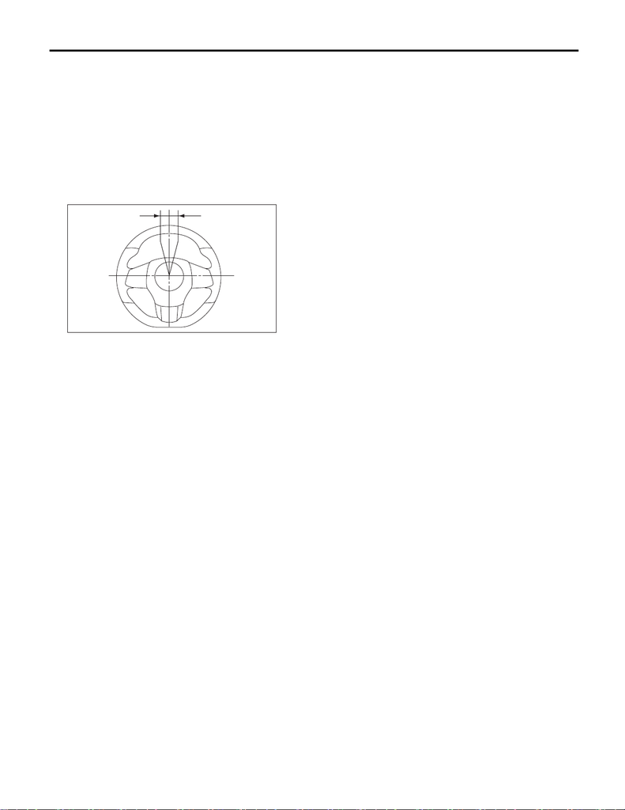

PM-32

Steering System (Power Steering)

PERIODIC MAINTENANCE SERVICES

25.Steering System (Power Steering)

A: INSPECTION

1. STEERING WHEEL

1) Set the steering wheel in a straight-ahead position, and check the wheel spokes to make sure they are cor-

rectly set in their specified positions.

2) Lightly turn the steering wheel to the left and right to determine the point where front wheels start to move.

Measure the distance of the movement of steering wheel (periphery).

Steering wheel free play:

0 — 17 mm (0 — 0.67 in)

Move the steering wheel vertically toward the shaft to check if there is play in the direction.

Play limit:

0.5 mm (0.020 in)

3) Drive the vehicle and check the following items.

(1) Steering force:

The effort required for steering should be smooth and even at all points, and should not vary.

(2) Pulled to one side:

Steering wheel should not be pulled to one side while driving on a level surface.

(3) Wheel runout:

Steering wheel should not show any sign of runout.

(4) Return status:

Steering wheel should return to its original position after it has been turned and then released.

2. STEERING SHAFT JOINT

If steering wheel play is excessive, disconnect the universal joint of steering shaft and then check the play

where the joints cross and yawing torque. Also, check the seal for damage or serrations for wear. If the joint

is loose, retighten the mounting bolts to the specified torque. <Ref. to PS-21, Universal Joint.>

Tightening torque:

24 N·m (2.4 kgf-m, 17.4 ft-lb)

(1)

PM-00763

(1) Steering wheel free play

15WRX_STI_US_EN.book 32 ページ ２０１５年２月１３日 金曜日 午前１１時２０分

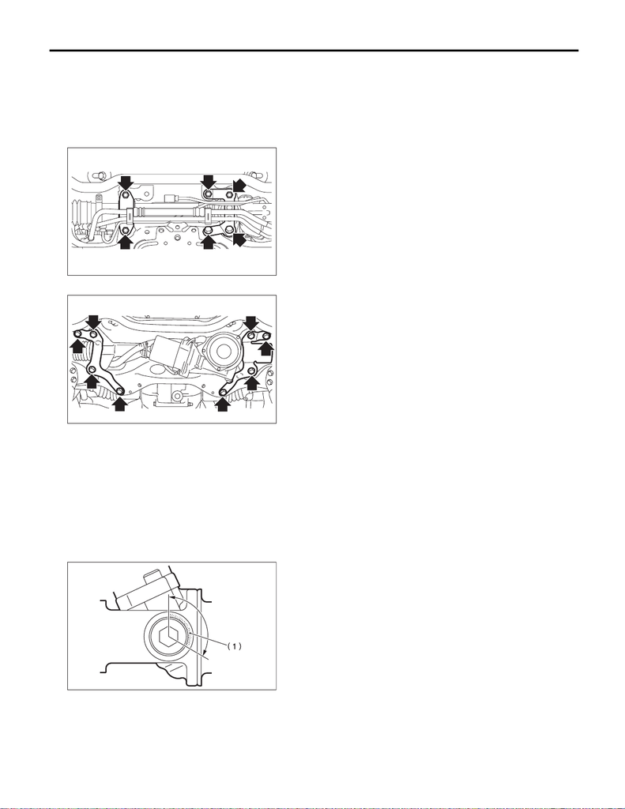

PM-33

Steering System (Power Steering)

PERIODIC MAINTENANCE SERVICES

3. GEARBOX

1) Set the steering wheel in the straight position, then rotate it 90° in both the left and right directions.

While steering wheel is being rotated, check the looseness of the gearbox.

Tightening torque:

60 N·m (6.1 kgf-m, 44.3 ft-lb)

• Hydraulic power steering

• Electric power steering

2) Check the boot for damage, cracks or deterioration.

3) With the vehicle stopped on a level surface, quickly turn the steering wheel to the left and right.

While steering wheel is being rotated, check the gear backlash. If any noise is noticed, adjust the gear back-

lash. <Ref. to PS-68, GEARBOX BACKLASH ADJUSTMENT, ADJUSTMENT, Electric Power Steering

Gearbox.>

Adjust the hydraulic power steering as follows.

(1) Loosen the adjusting screw, and apply liquid gasket to at least 1/3 of the entire perimeter of adjusting

screw thread.

Liquid gasket:

THREE BOND 1102

PM-00760

PM-00761

PS-00092

(1) Apply liquid gasket to 1/3 or more of the entire

perimeter.

15WRX_STI_US_EN.book 33 ページ ２０１５年２月１３日 金曜日 午前１１時２０分

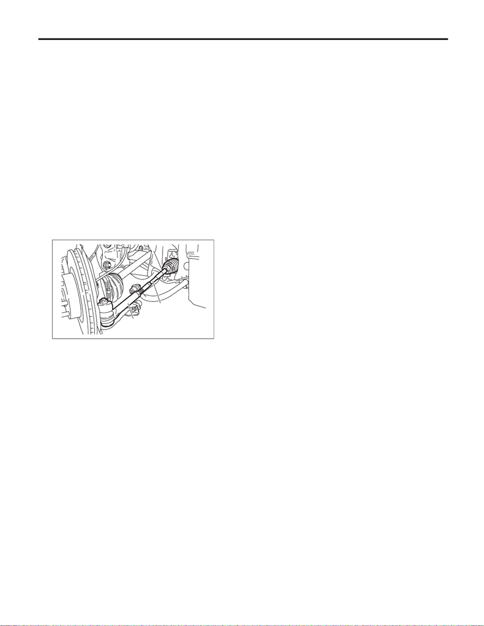

PM-34

Steering System (Power Steering)

PERIODIC MAINTENANCE SERVICES

(2) Tighten the adjusting screw, then loosen it.

CAUTION:

Adjust the steering rack to the straight forward position.

Tightening torque:

25 N·m (2.5 kgf-m, 18 ft-lb)

(3) Tighten the adjusting screw, then loosen it.

(4) Tighten the adjusting screw.

Tightening torque:

5.9 N·m (0.6 kgf-m, 4.2 ft-lb)

(5) Then, return the adjusting screw by 5° and fix it.

(6) Install the lock nut. While holding the adjusting screw with wrench, tighten the lock nut using ST.

ST 926230000 SPANNER

Tightening torque (lock nut):

25 N·m (2.5 kgf-m, 18 ft-lb)

Hold the adjusting screw with wrench to prevent it from turning while tightening the lock nut.

4. TIE-ROD

1) Check the tie-rod and tie-rod end for bend, cracks or other damages.

2) Confirm that the connections of knuckle ball joints for play, and then check for damage on dust boots and

free play of ball studs. If castle nut is loose, retighten it to the specified torque, then tighten further up to a

maximum of 60° until the cotter pin hole is aligned.

Tightening torque:

27 N·m (2.75 kgf-m, 19.9 ft-lb)

3) Check the tightening of tie-rod end lock nut. If it is loose, tighten it to the specified torque.

Tightening torque:

85 N·m (8.7 kgf-m, 62.7 ft-lb)

PM-00394

(A)

(B)

(A) Tie-rod end

(B) Tie-rod

15WRX_STI_US_EN.book 34 ページ ２０１５年２月１３日 金曜日 午前１１時２０分

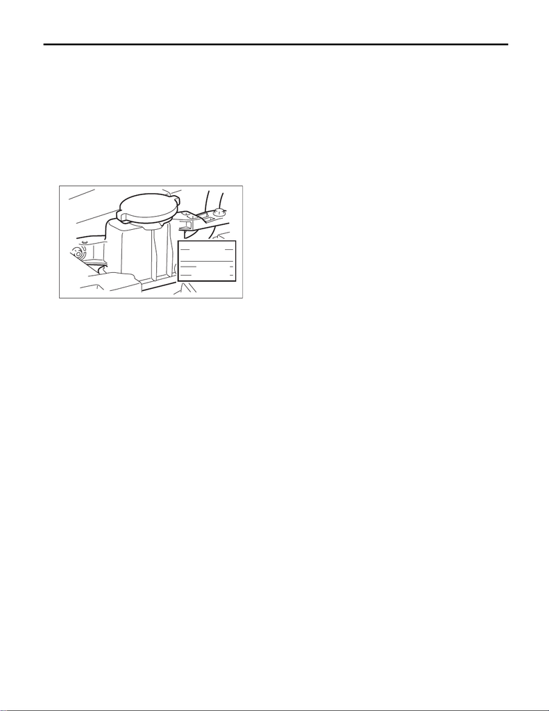

PM-35

Steering System (Power Steering)

PERIODIC MAINTENANCE SERVICES

5. POWER STEERING FLUID LEVEL

CAUTION:

If any power steering fluid is spilt over the exhaust pipe, wipe it off with a cloth to avoid emitting

smoke or causing a fire.

NOTE:

• For electric power steering model, inspection is not necessary.

• When the power steering fluid temperature is 20°C (68°F), check the fluid level on the “COLD” side.

• When the power steering fluid temperature is 80°C (176°F), check the fluid level on the “HOT” side.

1) Stop the engine to park the vehicle on a level surface.

2) Check the fluid level using the scale on the outside of the reservoir tank. If the level is below “MIN”, fill fluid

up to “MAX” level.

NOTE:

If fluid level is at “MAX” level or above, drain fluid to keep the level in the specified range of indicator by using

a syringe or the like.

Recommended fluid:

<Ref. to RM-4, FLUID, RECOMMENDED MATERIALS, Recommended Materials.>

Fluid capacity:

<Ref. to SPC-10, CAPACITY, WRX STI.>

6. POWER STEERING FLUID FOR LEAKS

CAUTION:

• Wipe the leaked fluid off after correcting fluid leaks.

• Also pay attention to interference between hoses or pipes and other parts when inspecting fluid

leaks.

• If any power steering fluid is spilt over the exhaust pipe, wipe it off with a cloth to avoid emitting

smoke or causing a fire.

For hydraulic power steering model, inspect the underside of oil pump, gearbox of power steering system,

hoses, pipes and their couplings for fluid leaks.

If fluid leakage is found, tighten the mounting bolt (or nut) again or replace with a new part.

7. HOSES OF OIL PUMP FOR DAMAGES

For model with hydraulic power steering, check the pressure hose or return hose of the oil pump for cracks,

swelling, damages. Replace the hose with a new part if necessary.

CAUTION:

When installing the hose, do not twist or bend.

8. POWER STEERING PIPES FOR DAMAGES

For model with hydraulic power steering, check the power steering pipe for corrosion or damages.

Replace the pipe with a new part if necessary.

PS-00463

HOT MAX

COLD MAX

HOT MIN

COLD MIN

15WRX_STI_US_EN.book 35 ページ ２０１５年２月１３日 金曜日 午前１１時２０分

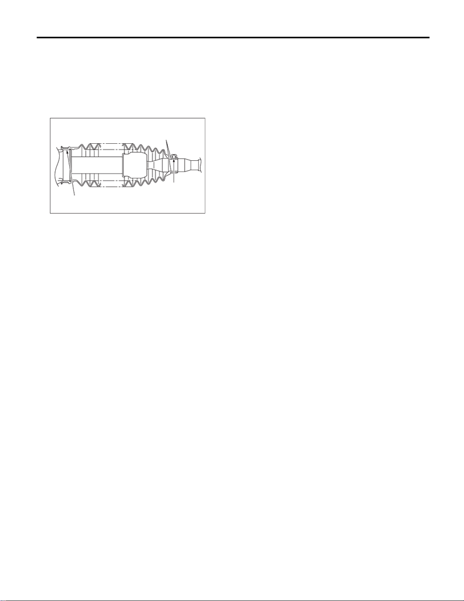

PM-36

Steering System (Power Steering)

PERIODIC MAINTENANCE SERVICES

9. GEARBOX BOOTS

Inspect both sides of the gearbox boot as follows, and correct the defects if necessary.

1) The (A) and (B) positions of the gearbox boot are fitted in (A) and (C) grooves of gearbox and the rod.

2) Clips are fitted onto the boot grooves to the positions (A) and (B) of the boot.

3) Check that there is no cracks or holes in the boot.

NOTE:

Rotate (B) position of gearbox boot against the torsion produced by the adjustment of toe-in etc.

10.MOUNTING BOLT & NUT

Inspect the fitting bolts and nuts of oil pump and bracket for looseness, and retighten them if necessary.

11.HARNESS INSPECTION (ELECTRIC POWER STEERING MODEL)

Check the harness of the electric power steering for cracks or damages.

Replace the electric power steering gear box with a new part if necessary.

12.ELECTRIC POWER STEERING CONTROL MODULE INSPECTION (ELECTRIC POWER

STEERING MODEL)

Check for the electric power steering diagnostic trouble codes. If the diagnostic trouble code is detected, per-

form the diagnosis. <Ref. to PS(diag)-2, Basic Diagnostic Procedure.>

Replace the control module, steering gear box with new parts if necessary.

(C)

(B)

(A)

PM-00090

15WRX_STI_US_EN.book 36 ページ ２０１５年２月１３日 金曜日 午前１１時２０分